# Data Science - Regressão Linear

## Preparação

Pacotes para aula.

```r
# install.packages("ftsa", dependencies = TRUE)
# install.packages("rsample", dependencies = TRUE)
# install.packages("car", dependencies = TRUE)
# install.packages("corrplot", dependencies = TRUE)
# install.packages("knitr", dependencies = TRUE)
# install.packages("tidyverse", dependencies = TRUE)
# install.packages("lubridate", dependencies = TRUE)
# install.packages("readr", dependencies = TRUE)
# install.packages("skimr", dependencies = TRUE)
# install.packages("broom", dependencies = TRUE)
# install.packages("GGally", dependencies = TRUE)

# Carrega pacote
library(rsample)
library(ftsa)
library(car)
library(corrplot)
library(knitr)
library(GGally)
library(tidyverse)
library(lubridate)
library(readr)
library(skimr)
library(broom)
```

## Regressão Linear Simples

### Exemplo simples para didática

A base de dados refere-se ao registro hipotético do consumo de kilos de sorvete e a temperatura média durante esse consumo.

```r
# Consumo de sorvete
consumoSorvete <- tibble(
  KgSorvete = c(
    400L,
    500L,
    700L,
    790L,
    870L,
    932L,
    1100L,
    1370L,
    1490L,
    1670L,
    1800L
  ),
  Temperatura = 22L:32L
)
```

### Dispersão dos dados (scartter plot)

Podemos observar no gráfico de dispersão dos dados que há uma tendência linear.

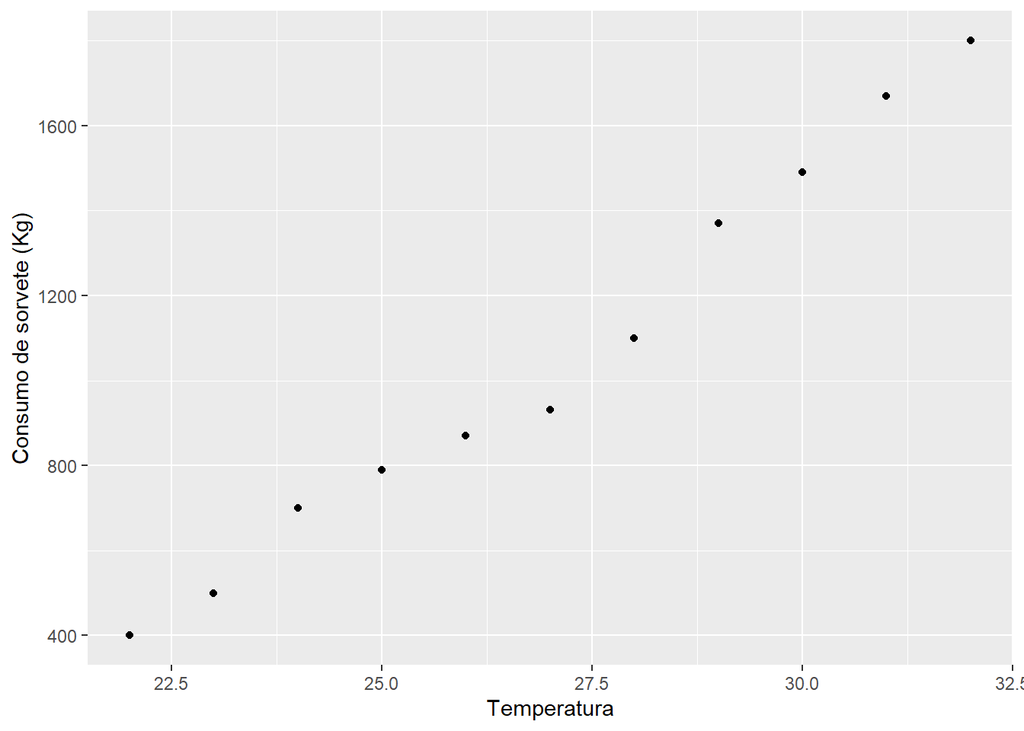

```r
grafico <- consumoSorvete %>%
  ggplot(
    aes(
      x = Temperatura,
      y = KgSorvete
    )
  ) +
  geom_point() +
  ylab(
    label = "Consumo de sorvete (Kg)"
  )

grafico
```

### Modelo de regressão linear simples

$$y = \alpha + \beta x + erro$$

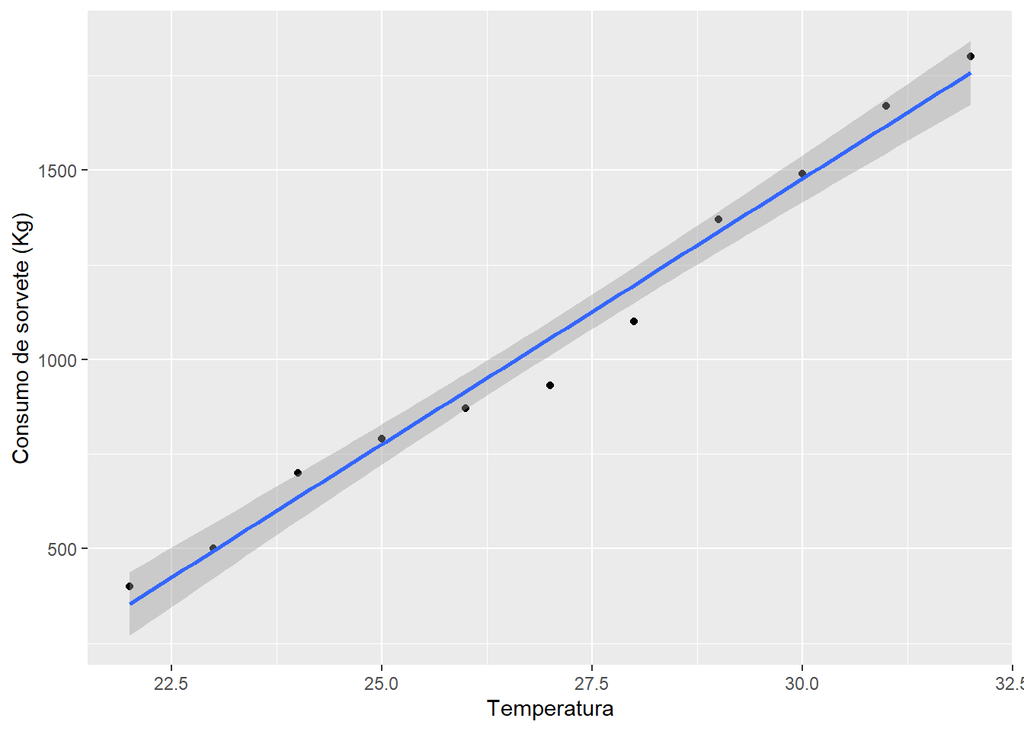

```r
modelo <- lm(
  formula = KgSorvete ~ Temperatura,
  data = consumoSorvete
)

grafico +
  stat_smooth(
    method = "lm",
    formula = y ~ x,
    geom = "smooth",
    se = TRUE,
    level = 0.95
  )
```

```r
# Resultados do modelo
summary(modelo)
```

```
##
## Call:
## lm(formula = KgSorvete ~ Temperatura, data = consumoSorvete)
##
## Residuals:
##     Min      1Q  Median      3Q     Max
## -124.55  -20.64   14.18   43.45   64.55
##
## Coefficients:
##              Estimate Std. Error t value Pr(>|t|)
## (Intercept) -2733.273    170.925  -15.99 6.46e-08 ***
## Temperatura   140.364      6.288   22.32 3.44e-09 ***
## ---
## Signif. codes:  0 '***' 0.001 '**' 0.01 '*' 0.05 '.' 0.1 ' ' 1
##
## Residual standard error: 65.94 on 9 degrees of freedom
## Multiple R-squared:  0.9823, Adjusted R-squared:  0.9803
## F-statistic: 498.4 on 1 and 9 DF,  p-value: 3.437e-09
```

Call: Indica a chamada da função utilizada para realizar a regressão linear.

Residuals: Resumo dos resíduos da regressão (diferença entre os valores reais e os valores previstos pelo modelo). Mostra o valor mínimo, primeiro quartil (25º percentil), mediana (50º percentil), terceiro quartil (75º percentil) e valor máximo dos resíduos.

Intercept: O coeficiente para o termo de intercepção (constante) $-2733.273$.

Temperatura: O coeficiente associado à variável independente Temperatura. Isso indica que, para cada aumento de uma unidade na temperatura, o valor previsto de KgSorvete aumenta em 140.364 unidades.

Significance codes: Os códigos de significância mostram o nível de significância estatística dos coeficientes. Neste caso, os coeficientes têm valores extremamente baixos (indicados por ’***’), o que significa que ambos os coeficientes são altamente significativos.

Residual standard error: Esta é uma estimativa do desvio padrão dos resíduos, que é uma medida da dispersão dos pontos em relação à linha de regressão. Quanto menor esse valor, melhor o ajuste do modelo aos dados observados.

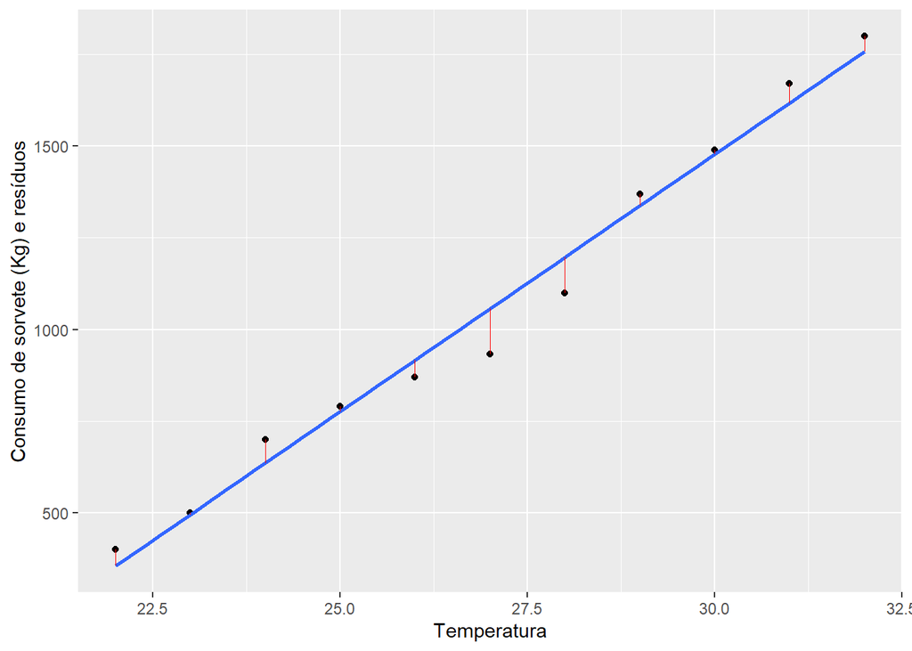

```r
modelo %>%
  augment() %>%
  ggplot(
    aes(
      x = Temperatura,
      y = KgSorvete
    )
  ) +
  geom_point() +
  stat_smooth(
    method = lm,
    se = FALSE
  ) +
  geom_segment(
    aes(
      xend = Temperatura,
      yend = .fitted
    ),
    color = "red",
    size = 0.3
  ) +
  ylab(
    label = "Consumo de sorvete (Kg) e resíduos"
  )
```

Degrees of freedom: Referem ao número de observações (pontos de dados) menos o número de parâmetros estimados no modelo (intercepto, inclinação, etc.).

- Número total de observações (pontos de dados): 11 (uma vez que há 11 valores para as variáveis `KgSorvete` e `Temperatura`).
- Número de parâmetros estimados no modelo: 2 (intercepto e coeficiente para Temperatura).

Portanto, os graus de liberdade do erro (residual) seriam $11 - 2 = 9$. O valor é utilizado para calcular a estatística F.

- F-statistic e p-value: A estatística F é usada para testar a significância geral do modelo de regressão. Com p-value extremamente baixo (3.437e-09), o modelo como um todo é altamente significativo.
- Multiple R-squared e Adjusted R-squared: O coeficiente de determinação (R-squared) é uma medida da proporção da variabilidade na variável dependente que é explicada pelo modelo. Cerca de 98.23% da variabilidade em `KgSorvete` é explicada pela variável `Temperatura`. O Adjusted R-squared leva em consideração o número de variáveis independentes no modelo e ajusta o R-squared para penalizar o uso excessivo de variáveis independentes.

Então, pela modelagem o $y$ é o consumo de sorvete em Kg. Assim, gostaríamos de estimar, considerando essa modelagem, qual seria o consumo de sorvete se a temperatura chegasse a 40°C ?

$$y = -2733.273 + (140.364 * x)$$

$$2881.287 = -2733.273 + (140.364 *
40)$$

O consumo de sorvete estimado é de 2881.287 Kg.

## Regressão Linear Multivariada

Nesse caso, há $n$ variáveis independentes.

$$y = \alpha + (\beta_1 * x_1) + \dots + (\beta_n * x_n) + err$$
### Carga dos dados

```r
# Carrega o arquivo csv
dados <- read_delim(
  file = "https://www.ufrgs.br/wiki-r/images/3/3d/Customer_shopping_data.csv",
  delim = ","
) %>%
  transmute(
    price,
    gender = factor(gender),
    age = as.integer(age),
    category = factor(category),
    payment_method = factor(payment_method),
    shopping_mall = factor(shopping_mall),
    Mes = month(invoice_date)
  )

# Dados originais
dados %>%
  head(n = 15) %>%
  kable()
```

| price | gender | age | category | payment_method | shopping_mall | Mes |
| --- | --- | --- | --- | --- | --- | --- |
| 1500.40 | Female | 28 | Clothing | Credit Card | Kanyon | 8 |
| 1800.51 | Male | 21 | Shoes | Debit Card | Forum Istanbul | 12 |
| 300.08 | Male | 20 | Clothing | Cash | Metrocity | 11 |
| 3000.85 | Female | 66 | Shoes | Credit Card | Metropol AVM | 5 |
| 60.60 | Female | 53 | Books | Cash | Kanyon | 10 |
| 1500.40 | Female | 28 | Clothing | Credit Card | Forum Istanbul | 5 |
| 40.66 | Female | 49 | Cosmetics | Cash | Istinye Park | 3 |
| 600.16 | Female | 32 | Clothing | Credit Card | Mall of Istanbul | 1 |
| 900.24 | Male | 69 | Clothing | Credit Card | Metrocity | 11 |
| 600.16 | Female | 60 | Clothing | Credit Card | Kanyon | 8 |
| 10.46 | Female | 36 | Food & Beverage | Cash | Metrocity | 12 |
| 15.15 | Female | 29 | Books | Credit Card | Emaar Square Mall | 10 |
| 143.36 | Female | 67 | Toys | Debit Card | Metrocity | 7 |
| 600.16 | Male | 25 | Clothing | Cash | Cevahir AVM | 11 |
| 600.16 | Female | 67 | Clothing | Credit Card | Kanyon | 6 |

### Modelo com todas as variáveis

```r
modelo <- lm(
  formula = price ~ .,
  data = dados
)

summary(modelo)
```

```
##
## Call:
## lm(formula = price ~ ., data = dados)
##
## Residuals:
##      Min       1Q   Median       3Q      Max
## -2116.14   -47.29    -1.22    52.19  2105.66
##
## Coefficients:
##                                  Estimate Std. Error t value Pr(>|t|)
## (Intercept)                      41.17912   11.33129   3.634 0.000279 ***
## genderMale                        0.64316    3.20505   0.201 0.840956
## age                               0.14179    0.10482   1.353 0.176185
## categoryClothing                855.59393    7.51131 113.907  < 2e-16 ***
## categoryCosmetics                76.91638    8.09730   9.499  < 2e-16 ***
## categoryFood & Beverage         -29.81157    8.11916  -3.672 0.000241 ***
## categoryShoes                  1761.85349    8.58921 205.124  < 2e-16 ***
## categorySouvenir                -10.63720    9.92112  -1.072 0.283643
## categoryTechnology             3111.47014    9.92213 313.589  < 2e-16 ***
## categoryToys                     62.22053    8.58180   7.250 4.19e-13 ***
## payment_methodCredit Card        -0.90159    3.54333  -0.254 0.799151
## payment_methodDebit Card         -3.43637    4.21365  -0.816 0.414769
## shopping_mallEmaar Square Mall   -1.14101   10.01207  -0.114 0.909267
## shopping_mallForum Istanbul       4.78178    9.94189   0.481 0.630537
## shopping_mallIstinye Park        -1.08163    8.61995  -0.125 0.900144
## shopping_mallKanyon               1.17437    7.84780   0.150 0.881047
## shopping_mallMall of Istanbul     0.62537    7.84286   0.080 0.936446
## shopping_mallMetrocity           -7.83371    8.09661  -0.968 0.333281
## shopping_mallMetropol AVM        -1.72576    8.56558  -0.201 0.840326
## shopping_mallViaport Outlet      -2.45982    9.95813  -0.247 0.804896
## shopping_mallZorlu Center         1.78343    9.87830   0.181 0.856729
## Mes                              -0.02029    0.44023  -0.046 0.963241
## ---
## Signif. codes:  0 '***' 0.001 '**' 0.01 '*' 0.05 '.' 0.1 ' ' 1
##
## Residual standard error: 495.5 on 99435 degrees of freedom
## Multiple R-squared:  0.7229, Adjusted R-squared:  0.7228
## F-statistic: 1.235e+04 on 21 and 99435 DF,  p-value: < 2.2e-16
```

Observem as médias por `category`.

```r
dados %>%
  select(category, price) %>%
  group_by(category) %>%
  skim()
```

Data summary

| Name | Piped data |
| --- | --- |
| Number of rows | 99457 |
| Number of columns | 2 |
| _______________________ |  |
| Column type frequency: |  |
| numeric | 1 |
| ________________________ |  |
| Group variables | category |

**Variable type: numeric**

| skim_variable | category | n_missing | complete_rate | mean | sd | p0 | p25 | p50 | p75 | p100 | hist |
| --- | --- | --- | --- | --- | --- | --- | --- | --- | --- | --- | --- |
| price | Books | 0 | 1 | 45.57 | 21.49 | 15.15 | 30.30 | 45.45 | 60.60 | 75.75 | ▇▇▇▇▇ |
| price | Clothing | 0 | 1 | 901.08 | 424.23 | 300.08 | 600.16 | 900.24 | 1200.32 | 1500.40 | ▇▇▇▇▇ |
| price | Cosmetics | 0 | 1 | 122.45 | 57.46 | 40.66 | 81.32 | 121.98 | 162.64 | 203.30 | ▇▇▇▇▇ |
| price | Food & Beverage | 0 | 1 | 15.67 | 7.42 | 5.23 | 10.46 | 15.69 | 20.92 | 26.15 | ▇▇▇▇▇ |
| price | Shoes | 0 | 1 | 1807.39 | 845.12 | 600.17 | 1200.34 | 1800.51 | 2400.68 | 3000.85 | ▇▇▇▇▇ |
| price | Souvenir | 0 | 1 | 34.89 | 16.56 | 11.73 | 23.46 | 35.19 | 46.92 | 58.65 | ▇▇▇▇▇ |
| price | Technology | 0 | 1 | 3156.94 | 1481.56 | 1050.00 | 2100.00 | 3150.00 | 4200.00 | 5250.00 | ▇▇▇▇▇ |
| price | Toys | 0 | 1 | 107.73 | 50.36 | 35.84 | 71.68 | 107.52 | 143.36 | 179.20 | ▇▇▇▇▇ |

### Modelo com seleção de variáveis

É recomentável reduzir a complexidade do modelo removendo variáveis irrelevantes, ruidozas ou correlacionadas. Um dos métodos recomendados para modelos de regressão é o Step Wise.

```r
modelo <- lm(
  formula = price ~ .,
  data = dados
) %>%
  step()
```

```
## Start:  AIC=1234401
## price ~ gender + age + category + payment_method + shopping_mall +
##     Mes
##
##                  Df  Sum of Sq        RSS     AIC
## - shopping_mall   9 1.0728e+06 2.4416e+10 1234387
## - payment_method  2 1.6394e+05 2.4415e+10 1234398
## - Mes             1 5.2200e+02 2.4414e+10 1234399
## - gender          1 9.8870e+03 2.4414e+10 1234399
## - age             1 4.4921e+05 2.4415e+10 1234401
## <none>                         2.4414e+10 1234401
## - category        7 6.3682e+10 8.8096e+10 1362015
##
## Step:  AIC=1234387
## price ~ gender + age + category + payment_method + Mes
##
##                  Df  Sum of Sq        RSS     AIC
## - payment_method  2 1.6452e+05 2.4416e+10 1234384
## - Mes             1 6.1300e+02 2.4416e+10 1234385
## - gender          1 9.4300e+03 2.4416e+10 1234385
## - age             1 4.4977e+05 2.4416e+10 1234387
## <none>                         2.4416e+10 1234387
## - category        7 6.3685e+10 8.8100e+10 1362002
##
## Step:  AIC=1234384
## price ~ gender + age + category + Mes
##
##            Df  Sum of Sq        RSS     AIC
## - Mes       1 5.9700e+02 2.4416e+10 1234382
## - gender    1 9.3680e+03 2.4416e+10 1234382
## - age       1 4.5112e+05 2.4416e+10 1234384
## <none>                   2.4416e+10 1234384
## - category  7 6.3685e+10 8.8100e+10 1361998
##
## Step:  AIC=1234382
## price ~ gender + age + category
##
##            Df  Sum of Sq        RSS     AIC
## - gender    1 9.3650e+03 2.4416e+10 1234380
## - age       1 4.5094e+05 2.4416e+10 1234382
## <none>                   2.4416e+10 1234382
## - category  7 6.3685e+10 8.8101e+10 1361996
##
## Step:  AIC=1234380
## price ~ age + category
##
##            Df  Sum of Sq        RSS     AIC
## - age       1 4.5066e+05 2.4416e+10 1234380
## <none>                   2.4416e+10 1234380
## - category  7 6.3685e+10 8.8101e+10 1361995
##
## Step:  AIC=1234380
## price ~ category
##
##            Df  Sum of Sq        RSS     AIC
## <none>                   2.4416e+10 1234380
## - category  7 6.3685e+10 8.8101e+10 1361993
```

```r
summary(modelo)
```

```
##
## Call:
## lm(formula = price ~ category, data = dados)
##
## Residuals:
##      Min       1Q   Median       3Q      Max
## -2106.94   -41.13    -0.47    40.19  2093.06
##
## Coefficients:
##                         Estimate Std. Error t value Pr(>|t|)
## (Intercept)               45.569      7.021   6.491 8.59e-11 ***
## categoryClothing         855.515      7.511 113.908  < 2e-16 ***
## categoryCosmetics         76.880      8.096   9.496  < 2e-16 ***
## categoryFood & Beverage  -29.897      8.118  -3.683 0.000231 ***
## categoryShoes           1761.820      8.588 205.142  < 2e-16 ***
## categorySouvenir         -10.674      9.920  -1.076 0.281905
## categoryTechnology      3111.367      9.921 313.604  < 2e-16 ***
## categoryToys              62.165      8.581   7.245 4.37e-13 ***
## ---
## Signif. codes:  0 '***' 0.001 '**' 0.01 '*' 0.05 '.' 0.1 ' ' 1
##
## Residual standard error: 495.5 on 99449 degrees of freedom
## Multiple R-squared:  0.7229, Adjusted R-squared:  0.7228
## F-statistic: 3.706e+04 on 7 and 99449 DF,  p-value: < 2.2e-16
```

## Regressão linear e correlações

### Carrega dados

```r
# Carrega o arquivo csv
dadosRealEstate <- read_delim(
  file = "https://www.ufrgs.br/wiki-r/images/5/5f/RealEstate.csv",
  delim = ","
) %>%
  select(-No) %>% # Remove o identificador de cada linha (ID)
  setNames(c("DataTransacao", "IdadeCasa", "DistanciaTransportePublico", "LojasProximas", "Latitude", "Longitude", "PrecoPorUnidadeArea"))

# Dados originais
dadosRealEstate %>%
  head(n = 15) %>%
  kable()
```

| DataTransacao | IdadeCasa | DistanciaTransportePublico | LojasProximas | Latitude | Longitude | PrecoPorUnidadeArea |
| --- | --- | --- | --- | --- | --- | --- |
| 2012.917 | 32.0 | 84.87882 | 10 | 24.98298 | 121.5402 | 37.9 |
| 2012.917 | 19.5 | 306.59470 | 9 | 24.98034 | 121.5395 | 42.2 |
| 2013.583 | 13.3 | 561.98450 | 5 | 24.98746 | 121.5439 | 47.3 |
| 2013.500 | 13.3 | 561.98450 | 5 | 24.98746 | 121.5439 | 54.8 |
| 2012.833 | 5.0 | 390.56840 | 5 | 24.97937 | 121.5425 | 43.1 |
| 2012.667 | 7.1 | 2175.03000 | 3 | 24.96305 | 121.5125 | 32.1 |
| 2012.667 | 34.5 | 623.47310 | 7 | 24.97933 | 121.5364 | 40.3 |
| 2013.417 | 20.3 | 287.60250 | 6 | 24.98042 | 121.5423 | 46.7 |
| 2013.500 | 31.7 | 5512.03800 | 1 | 24.95095 | 121.4846 | 18.8 |
| 2013.417 | 17.9 | 1783.18000 | 3 | 24.96731 | 121.5149 | 22.1 |
| 2013.083 | 34.8 | 405.21340 | 1 | 24.97349 | 121.5337 | 41.4 |
| 2013.333 | 6.3 | 90.45606 | 9 | 24.97433 | 121.5431 | 58.1 |
| 2012.917 | 13.0 | 492.23130 | 5 | 24.96515 | 121.5374 | 39.3 |
| 2012.667 | 20.4 | 2469.64500 | 4 | 24.96108 | 121.5105 | 23.8 |
| 2013.500 | 13.2 | 1164.83800 | 4 | 24.99156 | 121.5341 | 34.3 |

#### Análise descritiva

```r
# Dados originais
dadosRealEstate %>%
  skim()
```

Data summary

| Name | Piped data |
| --- | --- |
| Number of rows | 414 |
| Number of columns | 7 |
| _______________________ |  |
| Column type frequency: |  |
| numeric | 7 |
| ________________________ |  |
| Group variables | None |

**Variable type: numeric**

| skim_variable | n_missing | complete_rate | mean | sd | p0 | p25 | p50 | p75 | p100 | hist |
| --- | --- | --- | --- | --- | --- | --- | --- | --- | --- | --- |
| DataTransacao | 0 | 1 | 2013.15 | 0.28 | 2012.67 | 2012.92 | 2013.17 | 2013.42 | 2013.58 | ▆▅▅▃▇ |
| IdadeCasa | 0 | 1 | 17.71 | 11.39 | 0.00 | 9.03 | 16.10 | 28.15 | 43.80 | ▆▇▃▅▂ |
| DistanciaTransportePublico | 0 | 1 | 1083.89 | 1262.11 | 23.38 | 289.32 | 492.23 | 1454.28 | 6488.02 | ▇▂▁▁▁ |
| LojasProximas | 0 | 1 | 4.09 | 2.95 | 0.00 | 1.00 | 4.00 | 6.00 | 10.00 | ▇▅▆▃▂ |
| Latitude | 0 | 1 | 24.97 | 0.01 | 24.93 | 24.96 | 24.97 | 24.98 | 25.01 | ▁▅▇▂▁ |
| Longitude | 0 | 1 | 121.53 | 0.02 | 121.47 | 121.53 | 121.54 | 121.54 | 121.57 | ▁▁▂▇▁ |
| PrecoPorUnidadeArea | 0 | 1 | 37.98 | 13.61 | 7.60 | 27.70 | 38.45 | 46.60 | 117.50 | ▅▇▂▁▁ |

#### Remoção de outliers

```r
# Dados originais
dados <- dadosRealEstate %>%
  filter(
    PrecoPorUnidadeArea > quantile(PrecoPorUnidadeArea, 0.025),
    PrecoPorUnidadeArea < quantile(PrecoPorUnidadeArea, 0.975),
    DistanciaTransportePublico < quantile(DistanciaTransportePublico, 0.95)
  )

# Dados originais
dados %>%
  skim()
```

Data summary

| Name | Piped data |
| --- | --- |
| Number of rows | 373 |
| Number of columns | 7 |
| _______________________ |  |
| Column type frequency: |  |
| numeric | 7 |
| ________________________ |  |
| Group variables | None |

**Variable type: numeric**

| skim_variable | n_missing | complete_rate | mean | sd | p0 | p25 | p50 | p75 | p100 | hist |
| --- | --- | --- | --- | --- | --- | --- | --- | --- | --- | --- |
| DataTransacao | 0 | 1 | 2013.15 | 0.28 | 2012.67 | 2012.92 | 2013.17 | 2013.42 | 2013.58 | ▆▅▅▃▇ |
| IdadeCasa | 0 | 1 | 17.47 | 11.36 | 0.00 | 8.50 | 15.90 | 27.60 | 43.80 | ▆▇▃▅▂ |
| DistanciaTransportePublico | 0 | 1 | 855.29 | 869.37 | 23.38 | 289.32 | 488.82 | 1360.14 | 4079.42 | ▇▂▂▁▁ |
| LojasProximas | 0 | 1 | 4.31 | 2.85 | 0.00 | 2.00 | 5.00 | 6.00 | 10.00 | ▇▆▇▅▂ |
| Latitude | 0 | 1 | 24.97 | 0.01 | 24.93 | 24.96 | 24.97 | 24.98 | 25.01 | ▁▃▇▂▁ |
| Longitude | 0 | 1 | 121.54 | 0.01 | 121.50 | 121.53 | 121.54 | 121.54 | 121.57 | ▂▂▇▇▁ |
| PrecoPorUnidadeArea | 0 | 1 | 38.69 | 10.93 | 13.80 | 29.70 | 39.40 | 46.60 | 63.20 | ▂▆▇▆▂ |

### Correlações

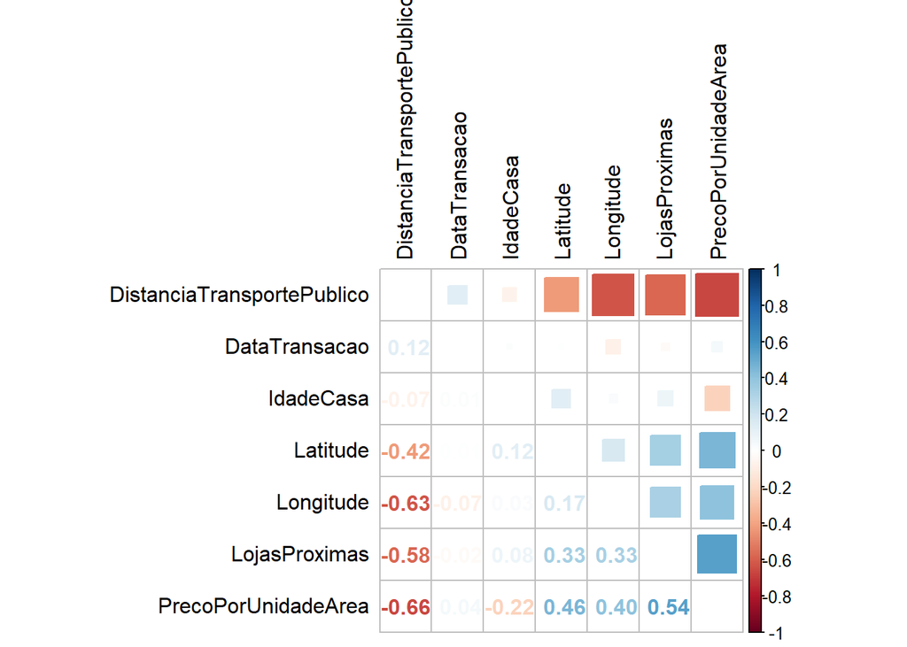

```r
corrplot.mixed(
  corr = dados %>%
    cor(),
  order = "FPC",
  lower = "number",
  upper = "square",
  tl.pos = "lt",
  tl.col = "black"
)
```

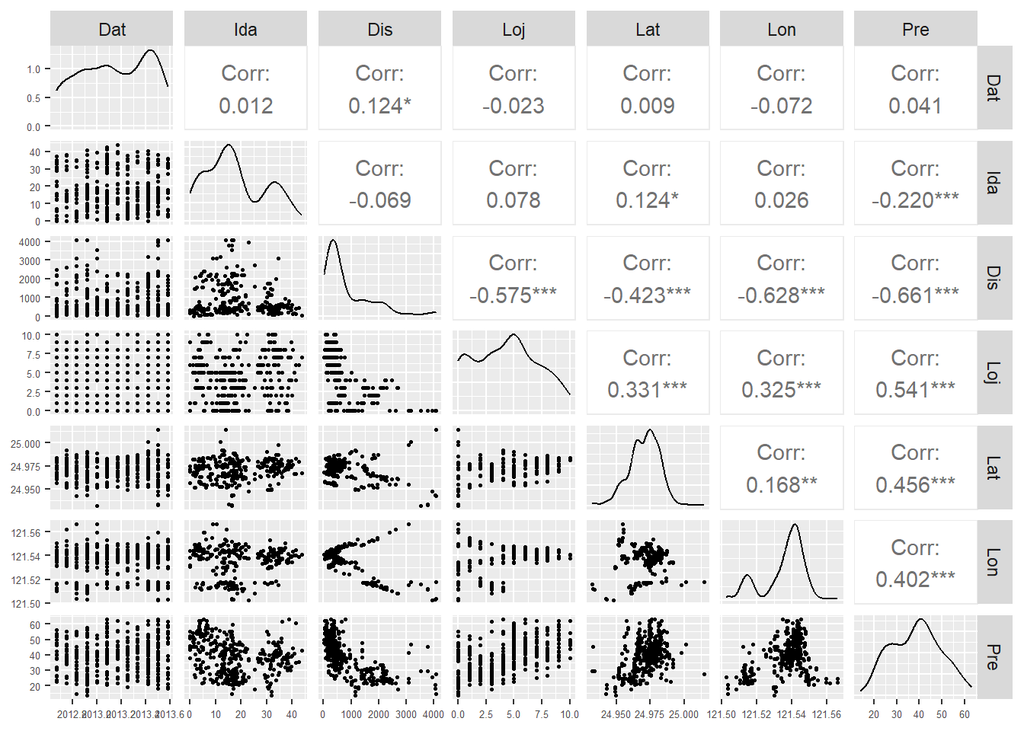

```r
dados %>%
  rename_all(
    .funs = str_sub, end = 3
  ) %>%
  ggpairs(
    lower = list(continuous = wrap("points", size = 0.5))
  ) +
  theme(
    axis.text.x = element_text(
      size = 5
    ),
    axis.text.y = element_text(
      size = 5
    )
  )
```

### Modelo de regressão

```r
# Cria modelo
modelo <- lm(
  formula = PrecoPorUnidadeArea ~ .,
  data = dados
)

# Informacoes do modelo
summary(modelo)
```

```
##
## Call:
## lm(formula = PrecoPorUnidadeArea ~ ., data = dados)
##
## Residuals:
##     Min      1Q  Median      3Q     Max
## -16.586  -4.528  -0.666   3.578  33.844
##
## Coefficients:
##                              Estimate Std. Error t value Pr(>|t|)
## (Intercept)                -1.576e+04  5.465e+03  -2.884  0.00416 **
## DataTransacao               4.102e+00  1.290e+00   3.180  0.00160 **
## IdadeCasa                  -2.874e-01  3.194e-02  -8.999  < 2e-16 ***
## DistanciaTransportePublico -5.786e-03  6.557e-04  -8.825  < 2e-16 ***
## LojasProximas               8.573e-01  1.561e-01   5.491 7.50e-08 ***
## Latitude                    2.161e+02  3.637e+01   5.942 6.56e-09 ***
## Longitude                   1.769e+01  3.853e+01   0.459  0.64635
## ---
## Signif. codes:  0 '***' 0.001 '**' 0.01 '*' 0.05 '.' 0.1 ' ' 1
##
## Residual standard error: 6.94 on 366 degrees of freedom
## Multiple R-squared:  0.6036, Adjusted R-squared:  0.5971
## F-statistic: 92.88 on 6 and 366 DF,  p-value: < 2.2e-16
```

### Modelo de regressão com step wise

```r
# Cria modelo
modeloStep <- lm(
  formula = PrecoPorUnidadeArea ~ .,
  data = dados
) %>%
  step()
```

```
## Start:  AIC=1452.14
## PrecoPorUnidadeArea ~ DataTransacao + IdadeCasa + DistanciaTransportePublico +
##     LojasProximas + Latitude + Longitude
##
##                              Df Sum of Sq   RSS    AIC
## - Longitude                   1      10.2 17637 1450.3
## <none>                                    17627 1452.1
## - DataTransacao               1     487.0 18114 1460.3
## - LojasProximas               1    1451.9 19079 1479.7
## - Latitude                    1    1700.5 19327 1484.5
## - DistanciaTransportePublico  1    3750.7 21378 1522.1
## - IdadeCasa                   1    3899.9 21527 1524.7
##
## Step:  AIC=1450.35
## PrecoPorUnidadeArea ~ DataTransacao + IdadeCasa + DistanciaTransportePublico +
##     LojasProximas + Latitude
##
##                              Df Sum of Sq   RSS    AIC
## <none>                                    17637 1450.3
## - DataTransacao               1     489.9 18127 1458.6
## - LojasProximas               1    1444.4 19081 1477.7
## - Latitude                    1    1695.7 19333 1482.6
## - IdadeCasa                   1    3902.3 21539 1522.9
## - DistanciaTransportePublico  1    5940.9 23578 1556.6
```

```r
# Informacoes do modelo
summary(modeloStep)
```

```
##
## Call:
## lm(formula = PrecoPorUnidadeArea ~ DataTransacao + IdadeCasa +
##     DistanciaTransportePublico + LojasProximas + Latitude, data = dados)
##
## Residuals:
##     Min      1Q  Median      3Q     Max
## -16.484  -4.424  -0.692   3.744  33.829
##
## Coefficients:
##                              Estimate Std. Error t value Pr(>|t|)
## (Intercept)                -1.358e+04  2.693e+03  -5.041 7.29e-07 ***
## DataTransacao               4.113e+00  1.288e+00   3.193  0.00153 **
## IdadeCasa                  -2.875e-01  3.190e-02  -9.011  < 2e-16 ***
## DistanciaTransportePublico -5.960e-03  5.360e-04 -11.119  < 2e-16 ***
## LojasProximas               8.543e-01  1.558e-01   5.482 7.83e-08 ***
## Latitude                    2.139e+02  3.601e+01   5.940 6.62e-09 ***
## ---
## Signif. codes:  0 '***' 0.001 '**' 0.01 '*' 0.05 '.' 0.1 ' ' 1
##
## Residual standard error: 6.932 on 367 degrees of freedom
## Multiple R-squared:  0.6034, Adjusted R-squared:  0.598
## F-statistic: 111.7 on 5 and 367 DF,  p-value: < 2.2e-16
```

### Predição

- Data da transação: $2013.15$
- Idade da casa: $17.47$
- Distância para o transporte público: $855.29$.
- Quantidade de lojas próximas: $4.31$.
- Latitude: $24.97$.

```r
predict(
  modeloStep,
  tibble(
    DataTransacao = 2013.15,
    IdadeCasa = 17.47,
    DistanciaTransportePublico = 855.29,
    LojasProximas = 4.31,
    Latitude = 24.97
  )
)
```

```
##        1
## 38.56772
```

## Referências

Bowerman, Bruce L. and O’Connell, Richard T. Linear Statistical Models. Duxbury classic series. Edição 2. Editora Thomson Wadsworth, 1990. ISBN 9780534923266

Field, A., Miles, J. and Field, Z. (2012) Discovering Statistics Using R. Sage Publications Ltd., London.

Heldt, Rodrigo. (2023) ANÁLISE DE PESQUISA EM ADMINISTRAÇÃO - Métodos Quantitativos. https://rheldt.com/regressaolinear.html#multicolinearidade

Menard, S. (1995). Applied logistic regression analysis (Sage university paper series on quantitative application in the social sciences, series no. 106) (2nd ed.). ThousandOaks, CA: Sage.